# CS 1675 Final Project: Part 2C

Regression Models

Anastasia Sosnovskikh

## Load packages

Load the packages used for EDA.

```r
library(tidyverse)
```

```r
library(dplyr)
library(ggplot2)
library(caret)
library(coefplot)
library(caret)
```

## Load Data

Read in the data.

```r
data_url <- 'https://raw.githubusercontent.com/jyurko/CS_1675_Fall_2020/master/HW/final_project/cs_1675_final_project_data.csv'

df_raw <- readr::read_csv(data_url, col_names = TRUE)
```

Separate the variables associated with Step 1.

```r
df_step1_inputs <- df_raw %>% select(xA, xB, x01:x06, response_1)
```

Separate the variables associated with the Option B classification formulation. The `outcome_2` variable is converted to a factor with a specific ordering of the levels. This ordering is used when modeling in `caret` to make sure everyone predicts the `Fail` class as the “positive” class in the confusion matrix.

```r
df_step2_B_inputs <- df_raw %>% select(xA, xB, response_1, x07:x11, outcome_2) %>%
  mutate(outcome_2 = factor(outcome_2, levels = c('Fail', 'Pass')))
```

Separate the variables associated with the Option A classification formulation. The `outcome_2` variable is again converted to a factor with a specific ordering of the levels.

```r
df_step2_A_inputs <- df_raw %>% select(xA, xB, x01:x11, outcome_2) %>%
  mutate(outcome_2 = factor(outcome_2, levels = c('Fail', 'Pass')))
```

Change data types for the whole data frame to perform EDA.

```r
df <- df_raw %>%
  mutate(xA = as.factor(xA),
         xB = as.factor(xB),
         outcome_2 = factor(outcome_2, levels = c('Fail', 'Pass')))
```

Standardize the data.

```r
get_standardized <- function(df) {
  predict(preProcess(df, method = c('center', 'scale')), df)
}
```

Some helper functions to get the features of a particualr type.

```r
get_CATEGORICAL_features_list <- function(df){
  colnames(df)[grepl('factor|logical|character',sapply(df,class))]
}
```

```r
get_CONTINIOUS_features_list <- function(df){
  df %>% select(-get_CATEGORICAL_features_list(df)) %>% colnames()
}
```

## Fit Linear Models

### Set the variables

#### Input data set

Define a data set to train on.

```r
df_input <- df_step1_inputs
```

*We train regression on step 1 inputs.*

#### Resampling Scheme

Define a resampling scheme.

```r
my_ctrl <- trainControl(method = 'repeatedcv',
                        number = 5,
                        repeats = 3)
```

*I will use repeated cross-validation by specifying the number of repeats to be `3` and number of folds to be `5`. Thus, the models will be trained and tested a total of `15` times.*

#### Performance Metric

Define a primary performance metric.

```r
reg_metric <- 'RMSE'
```

*Since we are doing regression, the valid regression evaluation metrics are: R-Squared, MAE, and Root Mean Squared Error (`RMSE`).*

*I don’t want to use MAE because I want my performance metric to be consistent with how the coefficients are estimated in the first place.*

*Since the coefficients are estimated by minimizing the error, I am left with `RMSE` and `r-squared` as performance evaluation models for the regression problem I am trying to solve.*

*I don’t want to use R-Squared (ranges from 0 to 1) because it’s the worst one from the list. It doesn’t measure goodness of fit very well. It can be arbitrarily low when the model is completely correct and it can be arbitrarily close to 1 when the model is wrong (sources: HOML book, https://data.library.virginia.edu/is-r-squared-useless/, and https://www.rpubs.com/frycast/rsq). Since the coefficients are estimated by minimizing the error, I am left with RMSE as a performance evaluation model for the regression problem I am trying to solve.*

#### Preprocessing scheme

Define pre-processing scheme.

```r
prep_scheme <- c('center', 'scale')
```

*I want to standardize the input.*

### Fitting the Models

#### Linear additive model (method=‘lm’)

Provide a baseline comparison to the other models by fitting the linear model.

```r
set.seed(1234)
fit_lm <- train(response_1 ~ .,
                data = df_input,
                method = 'lm',
                metric = reg_metric,
                preProcess = prep_scheme,
                trControl = my_ctrl)

fit_lm
```

```
## Linear Regression
##
## 2013 samples
##    8 predictor
##
## Pre-processing: centered (10), scaled (10)
## Resampling: Cross-Validated (5 fold, repeated 3 times)
## Summary of sample sizes: 1609, 1611, 1611, 1611, 1610, 1609, ...
## Resampling results:
##
##   RMSE      Rsquared   MAE
##   3.861907  0.4920216  2.79178
##
## Tuning parameter 'intercept' was held constant at a value of TRUE
```

#### Regularized regression with Elastic net (method=‘glmnet’)

Fit the model.

```r
set.seed(1234)
fit_elastic_add <- train(response_1 ~ .,
                    data = df_input,
                    method = 'glmnet',
                    metric = reg_metric,
                    preProcess = prep_scheme,
                    trControl = my_ctrl)

fit_elastic_add
```

```
## glmnet
##
## 2013 samples
##    8 predictor
##
## Pre-processing: centered (10), scaled (10)
## Resampling: Cross-Validated (5 fold, repeated 3 times)
## Summary of sample sizes: 1609, 1611, 1611, 1611, 1610, 1609, ...
## Resampling results across tuning parameters:
##
##   alpha  lambda       RMSE      Rsquared   MAE
##   0.10   0.005591724  3.861679  0.4920334  2.788987
##   0.10   0.055917239  3.861890  0.4920097  2.784312
##   0.10   0.559172389  3.905267  0.4875898  2.768251
##   0.55   0.005591724  3.861604  0.4920639  2.789652
##   0.55   0.055917239  3.862946  0.4918515  2.781958
##   0.55   0.559172389  3.972059  0.4791157  2.811122
##   1.00   0.005591724  3.861608  0.4920672  2.789986
##   1.00   0.055917239  3.865286  0.4914199  2.780648
##   1.00   0.559172389  4.067434  0.4650995  2.878170
##
## RMSE was used to select the optimal model using the smallest value.
## The final values used for the model were alpha = 0.55 and lambda = 0.005591724.
```

Print out the best tuning parameters.

```r
fit_elastic_add$bestTune
```

```
##   alpha      lambda
## 4  0.55 0.005591724
```

*This model favors Lasso slightly.*

Consider all **pair** interactions between all of the input variables and fit the model.

```r
set.seed(1234)
fit_elastic_pairs <- train(response_1 ~ (.)^2,
                    data = df_input,
                    method = 'glmnet',
                    metric = reg_metric,
                    preProcess = prep_scheme,
                    trControl = my_ctrl)

fit_elastic_pairs
```

```
## glmnet
##
## 2013 samples
##    8 predictor
##
## Pre-processing: centered (52), scaled (52)
## Resampling: Cross-Validated (5 fold, repeated 3 times)
## Summary of sample sizes: 1609, 1611, 1611, 1611, 1610, 1609, ...
## Resampling results across tuning parameters:
##
##   alpha  lambda       RMSE      Rsquared   MAE
##   0.10   0.005603354  3.839848  0.4978467  2.772969
##   0.10   0.056033543  3.861605  0.4921910  2.784107
##   0.10   0.560335429  3.874009  0.4902363  2.772235
##   0.55   0.005603354  3.853051  0.4944442  2.781343
##   0.55   0.056033543  3.860422  0.4925278  2.777601
##   0.55   0.560335429  3.957442  0.4786589  2.806935
##   1.00   0.005603354  3.860043  0.4926153  2.784883
##   1.00   0.056033543  3.863188  0.4919847  2.774947
##   1.00   0.560335429  4.069154  0.4646077  2.879738
##
## RMSE was used to select the optimal model using the smallest value.
## The final values used for the model were alpha = 0.1 and lambda = 0.005603354.
```

Print out the best tuning parameters.

```r
fit_elastic_pairs$bestTune
```

```
##   alpha      lambda
## 1   0.1 0.005603354
```

*This model favors Ridge*.

Check the number of coefficients that must be learned.

```r
fit_elastic_pairs$coefnames %>% length()
```

```
## [1] 52
```

Consider all **triplet** interactions between all of the input variables and fit the model.

```r
set.seed(1234)
fit_elastic_triplets <- train(response_1 ~ (.)^3,
                    data = df_input,
                    method = 'glmnet',
                    metric = reg_metric,
                    preProcess = prep_scheme,
                    trControl = my_ctrl)

fit_elastic_triplets
```

```
## glmnet
##
## 2013 samples
##    8 predictor
##
## Pre-processing: centered (150), scaled (150)
## Resampling: Cross-Validated (5 fold, repeated 3 times)
## Summary of sample sizes: 1609, 1611, 1611, 1611, 1610, 1609, ...
## Resampling results across tuning parameters:
##
##   alpha  lambda       RMSE      Rsquared   MAE
##   0.10   0.005603354  3.803212  0.5070893  2.750776
##   0.10   0.056033543  3.860974  0.4923527  2.783959
##   0.10   0.560335429  3.873590  0.4899642  2.775173
##   0.55   0.005603354  3.827683  0.5009085  2.766815
##   0.55   0.056033543  3.860450  0.4925163  2.777799
##   0.55   0.560335429  3.957067  0.4784241  2.807432
##   1.00   0.005603354  3.839295  0.4979410  2.775064
##   1.00   0.056033543  3.863024  0.4920460  2.774708
##   1.00   0.560335429  4.069164  0.4645965  2.879761
##
## RMSE was used to select the optimal model using the smallest value.
## The final values used for the model were alpha = 0.1 and lambda = 0.005603354.
```

Print out the best tuning parameters.

```r
fit_elastic_pairs$bestTune
```

```
##   alpha      lambda
## 1   0.1 0.005603354
```

*This model favors Ridge.*

Check the number of coefficients that must be learned.

```r
fit_elastic_triplets$coefnames %>% length()
```

```
## [1] 150
```

#### Neural network

Fit the default Neural Network.

```r
set.seed(1234)
fit_nnet <- train(response_1 ~ .,
                  data = df_input,
                  method = 'nnet',
                  metric = reg_metric,
                  preProcess = prep_scheme,
                  trControl = my_ctrl,
                  trace = FALSE)

fit_nnet
```

```
## Neural Network
##
## 2013 samples
##    8 predictor
##
## Pre-processing: centered (10), scaled (10)
## Resampling: Cross-Validated (5 fold, repeated 3 times)
## Summary of sample sizes: 1609, 1611, 1611, 1611, 1610, 1609, ...
## Resampling results across tuning parameters:
##
##   size  decay  RMSE      Rsquared   MAE
##   1     0e+00  5.208418  0.1947851  3.613506
##   1     1e-04  5.169705  0.2509164  3.565724
##   1     1e-01  5.140979  0.3169637  3.531801
##   3     0e+00  5.198226  0.2031129  3.595780
##   3     1e-04  5.170690  0.2470911  3.562866
##   3     1e-01  5.125712  0.3607670  3.510385
##   5     0e+00  5.233067  0.1757196  3.629942
##   5     1e-04  5.152873  0.2825807  3.541226
##   5     1e-01  5.116368  0.3970591  3.492968
##
## RMSE was used to select the optimal model using the smallest value.
## The final values used for the model were size = 5 and decay = 0.1.
```

Print out the best tuning parameters.

```r
fit_nnet$bestTune
```

```
##   size decay
## 9    5   0.1
```

Tune the Neural Network.

`size` is the number of units in hidden layer (`nnet` fit a single hidden layer neural network) and `decay` is the regularization parameter to avoid over-fitting.

```r
set.seed(1234)
nnet_grid <- expand.grid(size = seq(from = 1, to = 20, by = 1),
                         decay = c(1e-4, 0.1, 0.5))

fit_nnet_tuned <- train(response_1 ~ .,
                  data = df_input,
                  tuneGrid = nnet_grid,
                  method = 'nnet',
                  metric = reg_metric,
                  preProcess = prep_scheme,
                  trControl = my_ctrl,
                  trace = FALSE)

fit_nnet_tuned
```

```
## Neural Network
##
## 2013 samples
##    8 predictor
##
## Pre-processing: centered (10), scaled (10)
## Resampling: Cross-Validated (5 fold, repeated 3 times)
## Summary of sample sizes: 1609, 1611, 1611, 1611, 1610, 1609, ...
## Resampling results across tuning parameters:
##
##   size  decay  RMSE      Rsquared   MAE
##    1    1e-04  5.159506  0.2746153  3.555725
##    1    1e-01  5.138859  0.3218266  3.530706
##    1    5e-01  5.137299  0.3405518  3.530034
##    2    1e-04  5.155338  0.2784570  3.549354
```

[output cut: 59 more lines]

Print out the best tuning parameters.

```r
fit_nnet_tuned$bestTune
```

```
##    size decay
## 57   19   0.5
```

#### Random Forest (RF)

The random forest model creates `500` bagged tree models. Compared to a standard bagged tree model, the random forest randomly selects the number of features to consider during the splitting process.

Train the standard Random Forest.

```r
set.seed(1234)
fit_rf <- train(response_1 ~ .,
                data = df_input,
                method = 'rf',
                metric = reg_metric,
                trControl = my_ctrl,
                importance = TRUE)

fit_rf
```

```
## Random Forest
##
## 2013 samples
##    8 predictor
##
## No pre-processing
## Resampling: Cross-Validated (5 fold, repeated 3 times)
## Summary of sample sizes: 1609, 1611, 1611, 1611, 1610, 1609, ...
## Resampling results across tuning parameters:
##
##   mtry  RMSE      Rsquared   MAE
##    2    3.080652  0.7373460  2.133256
##    6    2.265154  0.8335815  1.652708
##   10    2.263737  0.8291478  1.663915
##
## RMSE was used to select the optimal model using the smallest value.
## The final value used for the model was mtry = 10.
```

Print out the best tuning parameters.

```r
fit_rf$bestTune
```

```
##   mtry
## 3   10
```

Tune the Random Forest.

`mtry` is number of predictors sampled for splitting at each node.

```r
set.seed(1234)
rf_grid <- expand.grid(mtry = seq(from = 1, to = 10, by = 1))

fit_rf_tuned <- train(response_1 ~ .,
                data = df_input,
                tuneGrid = rf_grid,
                method = 'rf',
                metric = reg_metric,
                trControl = my_ctrl,
                importance = TRUE)

fit_rf_tuned
```

```
## Random Forest
##
## 2013 samples
##    8 predictor
##
## No pre-processing
## Resampling: Cross-Validated (5 fold, repeated 3 times)
## Summary of sample sizes: 1609, 1611, 1611, 1611, 1610, 1609, ...
## Resampling results across tuning parameters:
##
##   mtry  RMSE      Rsquared   MAE
##    1    4.223982  0.5547184  2.922331
##    2    3.076395  0.7383660  2.128633
##    3    2.585576  0.8016423  1.809620
##    4    2.398478  0.8210215  1.709255
##    5    2.311448  0.8295041  1.672030
##    6    2.264163  0.8337380  1.650158
##    7    2.248097  0.8342937  1.647761
##    8    2.253843  0.8322038  1.655308
##    9    2.254444  0.8311624  1.657256
##   10    2.267341  0.8285548  1.664517
##
## RMSE was used to select the optimal model using the smallest value.
## The final value used for the model was mtry = 7.
```

Print out the best tuning parameters.

```r
fit_rf_tuned$bestTune
```

```
##   mtry
## 7    7
```

#### Gradient boosted tree

Fit the Gradient Boosted Tree.

```r
set.seed(1234)
fit_xgb <- train(response_1 ~ .,
                data = df_input,
                method = 'xgbTree',
                metric = reg_metric,
                trControl = my_ctrl)
```

[output not shown]

[output cut: 486 more lines]

[output not shown]

```r
fit_xgb
```

```
## eXtreme Gradient Boosting
##
## 2013 samples
##    8 predictor
##
## No pre-processing
## Resampling: Cross-Validated (5 fold, repeated 3 times)
## Summary of sample sizes: 1609, 1611, 1611, 1611, 1610, 1609, ...
## Resampling results across tuning parameters:
##
##   eta  max_depth  colsample_bytree  subsample  nrounds  RMSE      Rsquared
##   0.3  1          0.6               0.50        50      4.013047  0.4530630
##   0.3  1          0.6               0.50       100      4.030688  0.4474956
##   0.3  1          0.6               0.50       150      4.038145  0.4457080
##   0.3  1          0.6               0.75        50      4.004290  0.4558870
##   0.3  1          0.6               0.75       100      4.028237  0.4481511
##   0.3  1          0.6               0.75       150      4.029754  0.4481834
##   0.3  1          0.6               1.00        50      3.959965  0.4688861
##   0.3  1          0.6               1.00       100      3.984956  0.4609800
##   0.3  1          0.6               1.00       150      4.010285  0.4543296
##   0.3  1          0.8               0.50        50      4.013743  0.4519872
##   0.3  1          0.8               0.50       100      4.036722  0.4447641
##   0.3  1          0.8               0.50       150      4.058288  0.4399284
##   0.3  1          0.8               0.75        50      3.991436  0.4598918
##   0.3  1          0.8               0.75       100      4.027655  0.4487663
##   0.3  1          0.8               0.75       150      4.049630  0.4429696
##   0.3  1          0.8               1.00        50      3.958321  0.4694934
##   0.3  1          0.8               1.00       100      3.983363  0.4612256
##   0.3  1          0.8               1.00       150      4.011400  0.4538911
##   0.3  2          0.6               0.50        50      3.198017  0.6533453
##   0.3  2          0.6               0.50       100      3.015602  0.6901258
##   0.3  2          0.6               0.50       150      2.881133  0.7173027
##   0.3  2          0.6               0.75        50      3.175090  0.6600725
##   0.3  2          0.6               0.75       100      2.974220  0.7009354
##   0.3  2          0.6               0.75       150      2.849463  0.7254310
##   0.3  2          0.6               1.00        50      3.121103  0.6753345
##   0.3  2          0.6               1.00       100      2.936820  0.7101049
##   0.3  2          0.6               1.00       150      2.809866  0.7341481
##   0.3  2          0.8               0.50        50      3.090240  0.6797170
##   0.3  2          0.8               0.50       100      2.866477  0.7233849
```

[output cut: 181 more lines]

```
##   1.898733
##   1.842780
##   1.774306
##   1.774059
##   1.837418
##   1.748079
##   1.749170
##
## Tuning parameter 'gamma' was held constant at a value of 0
## Tuning
##  parameter 'min_child_weight' was held constant at a value of 1
## RMSE was used to select the optimal model using the smallest value.
## The final values used for the model were nrounds = 150, max_depth = 3, eta
##  = 0.3, gamma = 0, colsample_bytree = 0.8, min_child_weight = 1 and subsample
##  = 1.
```

Print out the best tuning parameters.

```r
fit_xgb$bestTune
```

```
##    nrounds max_depth eta gamma colsample_bytree min_child_weight subsample
## 54     150         3 0.3     0              0.8                1         1
```

Plot the cross-validation results.

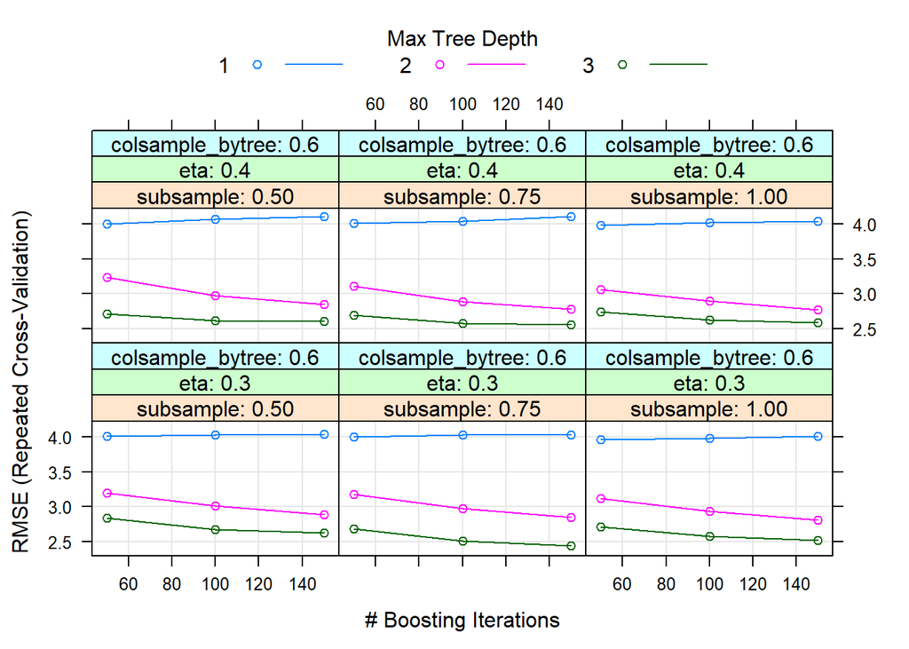

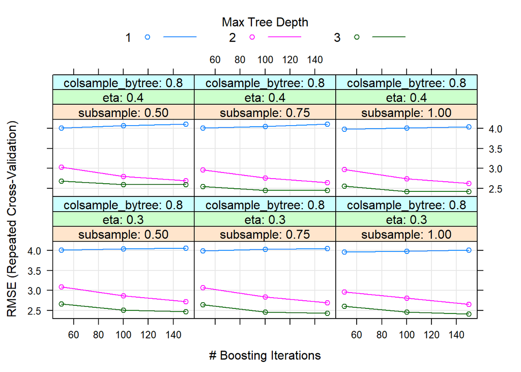

```r
fit_xgb %>% plot()
```

Tune the Gradient Booster Tree model.

- `nrounds` controls the maximum number of iterations. For classification, it is similar to the number of trees to grow.
- `eta` controls the learning rate, i.e., the rate at which our model learns patterns in data. After every round, it shrinks the feature weights to reach the best optimum. Lower eta leads to slower computation. It must be supported by increase in `nrounds`.
- `max_depth` controls the depth of the tree.
- `gamma` controls regularization (or prevents overfitting). Higher the value, higher the regularization. Regularization means penalizing large coefficients which don’t improve the model’s performance. The default is 0 which means no regularization.
- `colsample_bytree` controls the number of features (variables) supplied to a tree. Typically, its values lie between (0.5,0.9).
- `min_child_weight`, in regression, it refers to the minimum number of instances required in a child node. In classification, if the leaf node has a minimum sum of instance weight (calculated by second order partial derivative) lower than min_child_weight, the tree splitting stops. In other words, it blocks the potential feature interactions to prevent overfitting.
- `subsample` controls the number of samples (observations) supplied to a tree. Typically, its values lie between (0.5-0.8).

*I will hold all the parameters constant except for `nrounds`, `max_depth`, and `eta`*.

```r
set.seed(1234)
xgb_grid <- expand.grid(nrounds = seq(from = 10, to = 100, by = 10),
                        max_depth = seq(from = 1, to = 6, by = 1),
                        eta = seq(from = 0.1, to = 0.8, by = 0.1),
                        gamma = 0,
                        colsample_bytree = 0.8,
                        min_child_weight = 1,
                        subsample = 1)

fit_xgb_tuned <- train(response_1 ~ .,
                       data = df_input,
                       tuneGrid = xgb_grid,
                       method = 'xgbTree',
                       metric = reg_metric,
                       trControl = my_ctrl)
```

[output not shown]

[output cut: 666 more lines]

[output not shown]

```r
fit_xgb_tuned
```

```
## eXtreme Gradient Boosting
##
## 2013 samples
##    8 predictor
##
## No pre-processing
## Resampling: Cross-Validated (5 fold, repeated 3 times)
## Summary of sample sizes: 1609, 1611, 1611, 1611, 1610, 1609, ...
## Resampling results across tuning parameters:
##
##   eta  max_depth  nrounds  RMSE      Rsquared   MAE
##   0.1  1           10      4.697862  0.3370127  3.305359
##   0.1  1           20      4.420151  0.4115679  3.101736
##   0.1  1           30      4.247485  0.4407508  2.985364
##   0.1  1           40      4.143691  0.4557131  2.914384
##   0.1  1           50      4.080413  0.4613757  2.872724
##   0.1  1           60      4.037882  0.4659700  2.842905
##   0.1  1           70      4.010833  0.4691825  2.815746
##   0.1  1           80      3.987321  0.4724860  2.791900
##   0.1  1           90      3.975185  0.4729160  2.775641
##   0.1  1          100      3.962056  0.4744065  2.761141
##   0.1  2           10      4.203903  0.5525229  2.965109
##   0.1  2           20      3.729420  0.6003188  2.666204
##   0.1  2           30      3.545712  0.6180350  2.534915
##   0.1  2           40      3.430135  0.6339986  2.439598
##   0.1  2           50      3.330039  0.6517981  2.360107
##   0.1  2           60      3.247483  0.6660912  2.299776
##   0.1  2           70      3.198135  0.6740496  2.262021
##   0.1  2           80      3.162872  0.6793704  2.231916
##   0.1  2           90      3.131120  0.6842725  2.207733
##   0.1  2          100      3.103210  0.6887199  2.188076
##   0.1  3           10      3.898181  0.6424800  2.752403
##   0.1  3           20      3.302504  0.6968780  2.369181
##   0.1  3           30      3.065976  0.7233214  2.200831
##   0.1  3           40      2.898586  0.7449871  2.080142
##   0.1  3           50      2.820435  0.7535468  2.014859
##   0.1  3           60      2.782614  0.7571317  1.980082
##   0.1  3           70      2.754340  0.7604028  1.959187
##   0.1  3           80      2.728680  0.7632602  1.937761
##   0.1  3           90      2.700454  0.7668723  1.918020
```

[output cut: 447 more lines]

```
##   0.8  6           70      2.970341  0.6989449  2.142796
##   0.8  6           80      2.972372  0.6986148  2.144837
##   0.8  6           90      2.972168  0.6986384  2.144558
##   0.8  6          100      2.973004  0.6984842  2.144826
##
## Tuning parameter 'gamma' was held constant at a value of 0
## Tuning
##
## Tuning parameter 'min_child_weight' was held constant at a value of 1
##
## Tuning parameter 'subsample' was held constant at a value of 1
## RMSE was used to select the optimal model using the smallest value.
## The final values used for the model were nrounds = 100, max_depth = 6, eta
##  = 0.1, gamma = 0, colsample_bytree = 0.8, min_child_weight = 1 and subsample
##  = 1.
```

Print out the best tuning parameters.

```r
fit_xgb_tuned$bestTune
```

```
##    nrounds max_depth eta gamma colsample_bytree min_child_weight subsample
## 60     100         6 0.1     0              0.8                1         1
```

Plot the cross-validation results.

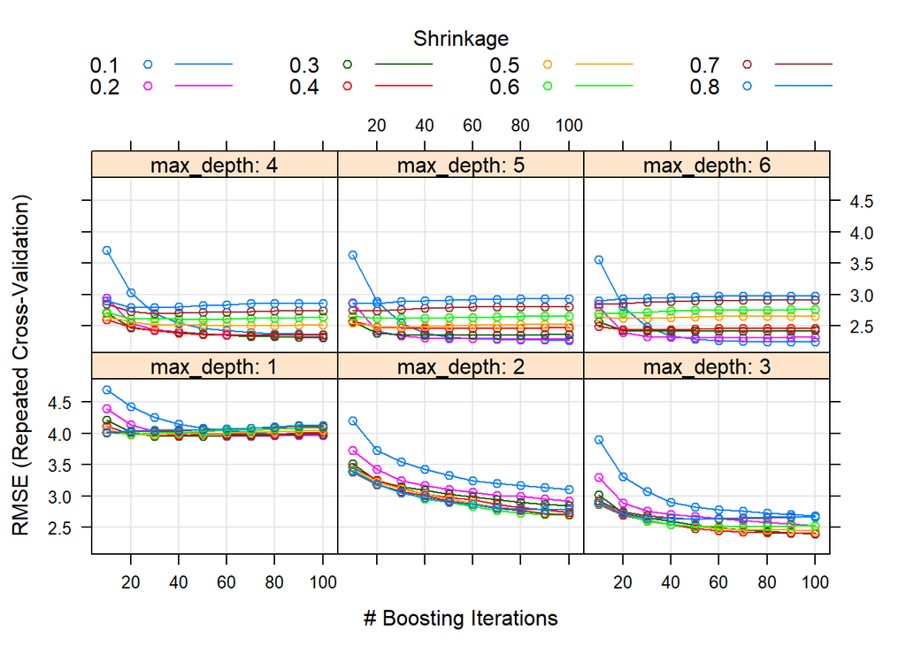

```r
fit_xgb_tuned %>% plot()
```

#### SVM

Fit the Support Vector Machine.

```r
set.seed(1234)
fit_svm <- train(response_1 ~ .,
                 data = df_input,
                 method = 'svmRadial',
                 metric = reg_metric,
                 preProcess = prep_scheme,
                 trControl = my_ctrl)

fit_svm
```

```
## Support Vector Machines with Radial Basis Function Kernel
##
## 2013 samples
##    8 predictor
##
## Pre-processing: centered (10), scaled (10)
## Resampling: Cross-Validated (5 fold, repeated 3 times)
## Summary of sample sizes: 1609, 1611, 1611, 1611, 1610, 1609, ...
## Resampling results across tuning parameters:
##
##   C     RMSE      Rsquared   MAE
##   0.25  3.588354  0.6010021  2.371122
##   0.50  3.209319  0.6875484  2.150621
##   1.00  2.763332  0.7697171  1.902934
##
## Tuning parameter 'sigma' was held constant at a value of 0.06965707
## RMSE was used to select the optimal model using the smallest value.
## The final values used for the model were sigma = 0.06965707 and C = 1.
```

Print out the best tuning parameters.

```r
fit_svm$bestTune
```

```
##        sigma C
## 3 0.06965707 1
```

Tune the Support Vector Machine.

`C` is a regularization parameter that controls the trade off between a low training error and a low testing error (generalizability).

`sigma` (or sometimes `gamma`) parameter defines how far the influence of a single training example reaches, with low values meaning ‘far’ and high values meaning ‘close’.

```r
set.seed(1234)
svm_grid <- expand.grid(C = seq(from = 0.1, to = 2, by = 0.2),
                        sigma = seq(from = 0.01, to = 0.1, by = 0.02))

fit_svm_tuned <- train(response_1 ~ .,
                 data = df_input,
                 tuneGrid = svm_grid,
                 method = 'svmRadial',
                 metric = reg_metric,
                 preProcess = prep_scheme,
                 trControl = my_ctrl)

fit_svm_tuned
```

```
## Support Vector Machines with Radial Basis Function Kernel
##
## 2013 samples
##    8 predictor
##
## Pre-processing: centered (10), scaled (10)
## Resampling: Cross-Validated (5 fold, repeated 3 times)
## Summary of sample sizes: 1609, 1611, 1611, 1611, 1610, 1609, ...
## Resampling results across tuning parameters:
##
##   C    sigma  RMSE      Rsquared   MAE
##   0.1  0.01   4.168427  0.4708195  2.827879
##   0.1  0.03   4.021939  0.4900450  2.698561
##   0.1  0.05   3.977964  0.5030659  2.641583
##   0.1  0.07   3.947812  0.5181799  2.600707
##   0.1  0.09   3.928042  0.5321850  2.572260
##   0.3  0.01   3.966130  0.4915555  2.702899
##   0.3  0.03   3.818210  0.5290424  2.551509
##   0.3  0.05   3.653207  0.5770410  2.424151
##   0.3  0.07   3.497191  0.6225682  2.316743
##   0.3  0.09   3.381347  0.6572781  2.234994
##   0.5  0.01   3.902998  0.5026554  2.660622
##   0.5  0.03   3.707997  0.5546630  2.475490
##   0.5  0.05   3.445673  0.6266739  2.298179
##   0.5  0.07   3.205931  0.6883911  2.148437
##   0.5  0.09   3.056133  0.7229277  2.046717
##   0.7  0.01   3.869305  0.5094769  2.633582
##   0.7  0.03   3.626836  0.5741290  2.420115
##   0.7  0.05   3.277103  0.6655557  2.202612
##   0.7  0.07   2.990594  0.7318146  2.027460
##   0.7  0.09   2.839111  0.7594597  1.925864
##   0.9  0.01   3.845799  0.5140692  2.612029
##   0.9  0.03   3.552904  0.5917876  2.374239
##   0.9  0.05   3.130479  0.6975160  2.122584
##   0.9  0.07   2.827567  0.7597190  1.937805
##   0.9  0.09   2.700240  0.7798544  1.850572
##   1.1  0.01   3.825520  0.5181386  2.594782
##   1.1  0.03   3.483257  0.6083749  2.332776
##   1.1  0.05   3.005188  0.7226950  2.053743
##   1.1  0.07   2.700312  0.7791327  1.869042
```

[output cut: 9 more lines]

```
##   1.5  0.07   2.536605  0.8020961  1.780415
##   1.5  0.09   2.475123  0.8086978  1.732258
##   1.7  0.01   3.779966  0.5280783  2.555505
##   1.7  0.03   3.300410  0.6512863  2.228769
##   1.7  0.05   2.718407  0.7736327  1.896310
##   1.7  0.07   2.476632  0.8101055  1.748042
##   1.7  0.09   2.432316  0.8135047  1.711753
##   1.9  0.01   3.769012  0.5305458  2.545709
##   1.9  0.03   3.244742  0.6640791  2.198697
##   1.9  0.05   2.648250  0.7846669  1.857498
##   1.9  0.07   2.425148  0.8167063  1.720678
##   1.9  0.09   2.395590  0.8177229  1.694073
##
## RMSE was used to select the optimal model using the smallest value.
## The final values used for the model were sigma = 0.09 and C = 1.9.
```

Print out the best tuning parameters.

```r
fit_svm_tuned$bestTune
```

```
##    sigma   C
## 50  0.09 1.9
```

#### Partial Least Squares (PLS)

Fit the Partial Least Squares.

```r
set.seed(1234)
fit_pls <- train(response_1 ~ .,
                 data = df_input,
                 method = 'pls',
                 metric = reg_metric,
                 preProcess = prep_scheme,
                 trControl = my_ctrl)

fit_pls
```

```
## Partial Least Squares
##
## 2013 samples
##    8 predictor
##
## Pre-processing: centered (10), scaled (10)
## Resampling: Cross-Validated (5 fold, repeated 3 times)
## Summary of sample sizes: 1609, 1611, 1611, 1611, 1610, 1609, ...
## Resampling results across tuning parameters:
##
##   ncomp  RMSE      Rsquared   MAE
##   1      4.221052  0.3918085  3.084918
##   2      3.942906  0.4705856  2.804241
##   3      3.875412  0.4886629  2.807076
##
## RMSE was used to select the optimal model using the smallest value.
## The final value used for the model was ncomp = 3.
```

Print out the best tuning parameters.

```r
fit_pls$bestTune
```

```
##   ncomp
## 3     3
```

Tune the Partial Least Squares.

`ncomp` is the number of components to fit on.

```r
set.seed(1234)
pls_grid <- expand.grid(ncomp = seq(from = 1, to = 10, by = 1))

fit_pls_tuned <- train(response_1 ~ .,
                       data = df_input,
                       tuneGrid = pls_grid,
                       method = 'pls',
                       metric = reg_metric,
                       preProcess = prep_scheme,
                       trControl = my_ctrl)

fit_pls_tuned
```

```
## Partial Least Squares
##
## 2013 samples
##    8 predictor
##
## Pre-processing: centered (10), scaled (10)
## Resampling: Cross-Validated (5 fold, repeated 3 times)
## Summary of sample sizes: 1609, 1611, 1611, 1611, 1610, 1609, ...
## Resampling results across tuning parameters:
##
##   ncomp  RMSE      Rsquared   MAE
##    1     4.221052  0.3918085  3.084918
##    2     3.942906  0.4705856  2.804241
##    3     3.875412  0.4886629  2.807076
##    4     3.862700  0.4918191  2.792015
##    5     3.861929  0.4920124  2.791630
##    6     3.861900  0.4920235  2.791773
##    7     3.861908  0.4920215  2.791780
##    8     3.861907  0.4920216  2.791780
##    9     3.861907  0.4920216  2.791780
##   10     3.861907  0.4920216  2.791780
##
## RMSE was used to select the optimal model using the smallest value.
## The final value used for the model was ncomp = 6.
```

Print out the best tuning parameters.

```r
fit_pls_tuned$bestTune
```

```
##   ncomp
## 6     6
```

*Since Partial Least Squares are used for the problems with correlated inputs, the above models did not perform well. Thus, I want to try using interactions as well.*

Fit the Partial Least Squares with pairwise interactions.

```r
set.seed(1234)
fit_pls_pair <- train(response_1 ~ (.)^2,
                 data = df_input,
                 method = 'pls',
                 metric = reg_metric,
                 preProcess = prep_scheme,
                 trControl = my_ctrl)

fit_pls_pair
```

```
## Partial Least Squares
##
## 2013 samples
##    8 predictor
##
## Pre-processing: centered (52), scaled (52)
## Resampling: Cross-Validated (5 fold, repeated 3 times)
## Summary of sample sizes: 1609, 1611, 1611, 1611, 1610, 1609, ...
## Resampling results across tuning parameters:
##
##   ncomp  RMSE      Rsquared   MAE
##   1      4.545404  0.2941149  3.371363
##   2      3.965939  0.4639457  2.888818
##   3      3.886242  0.4853077  2.823229
##
## RMSE was used to select the optimal model using the smallest value.
## The final value used for the model was ncomp = 3.
```

Print out the best tuning parameters.

```r
fit_pls_pair$bestTune
```

```
##   ncomp
## 3     3
```

Tune the Partial Least Squares.

```r
set.seed(1234)
pls_grid <- expand.grid(ncomp = seq(from = 1, to = 10, by = 1))

fit_pls_pair_tuned <- train(response_1 ~ (.)^2,
                       data = df_input,
                       tuneGrid = pls_grid,
                       method = 'pls',
                       metric = reg_metric,
                       preProcess = prep_scheme,
                       trControl = my_ctrl)

fit_pls_pair_tuned
```

```
## Partial Least Squares
##
## 2013 samples
##    8 predictor
##
## Pre-processing: centered (52), scaled (52)
## Resampling: Cross-Validated (5 fold, repeated 3 times)
## Summary of sample sizes: 1609, 1611, 1611, 1611, 1610, 1609, ...
## Resampling results across tuning parameters:
##
##   ncomp  RMSE      Rsquared   MAE
##    1     4.545404  0.2941149  3.371363
##    2     3.965939  0.4639457  2.888818
##    3     3.886242  0.4853077  2.823229
##    4     3.873460  0.4888371  2.797307
##    5     3.866535  0.4908173  2.787296
##    6     3.863425  0.4917169  2.786934
##    7     3.864803  0.4914088  2.790505
##    8     3.863702  0.4916873  2.790696
##    9     3.863093  0.4918745  2.787697
##   10     3.863933  0.4916686  2.787176
##
## RMSE was used to select the optimal model using the smallest value.
## The final value used for the model was ncomp = 9.
```

Print out the best tuning parameters.

```r
fit_pls_pair_tuned$bestTune
```

```
##   ncomp
## 9     9
```

*The performance did NOT improve. PLS is not a good model to use for this problem because the inputs are uncorrelated.*

#### Generalized Additive Models (GAM)

*Since PLS is not suited for this problem because the inputs are not correlated, I wanted to try GAM as well.*

Fit the Generalized Additive Model.

```r
set.seed(1234)
fit_gam <- train(response_1 ~ .,
                 data = df_input,
                 method = 'gam',
                 metric = reg_metric,
                 preProcess = prep_scheme,
                 trControl = my_ctrl)
fit_gam
```

```
## Generalized Additive Model using Splines
##
## 2013 samples
##    8 predictor
##
## Pre-processing: centered (10), scaled (10)
## Resampling: Cross-Validated (5 fold, repeated 3 times)
## Summary of sample sizes: 1609, 1611, 1611, 1611, 1610, 1609, ...
## Resampling results across tuning parameters:
##
##   select  RMSE      Rsquared   MAE
##   FALSE   3.863039  0.4927374  2.699445
##    TRUE   3.833664  0.4998806  2.683317
##
## Tuning parameter 'method' was held constant at a value of GCV.Cp
## RMSE was used to select the optimal model using the smallest value.
## The final values used for the model were select = TRUE and method = GCV.Cp.
```

Print out the best tuning parameters.

```r
fit_gam$bestTune
```

```
##   select method
## 2   TRUE GCV.Cp
```

## Assess Performance

Get a list of models.

```r
all_models <- list(LM = fit_lm,
                   GLMNET_ADD = fit_elastic_add,
                   GLMNET_PAIRS = fit_elastic_pairs,
                   GLMNET_TRIPLETS = fit_elastic_triplets,
                   NNET = fit_nnet,
                   NNET_tuned = fit_nnet_tuned,
                   RF = fit_rf,
                   RF_tuned = fit_rf_tuned,
                   XGB = fit_xgb,
                   XGB_tuned = fit_xgb_tuned,
                   SVM = fit_svm,
                   SVM_tuned = fit_svm_tuned,
                   PLS = fit_pls,
                   PLS_tuned = fit_pls_tuned,
                   PLS_PAIR = fit_pls_pair,
                   PLS_PAIR_tuned = fit_pls_pair_tuned,
                   GAM = fit_gam)
```

Plot the metrics.

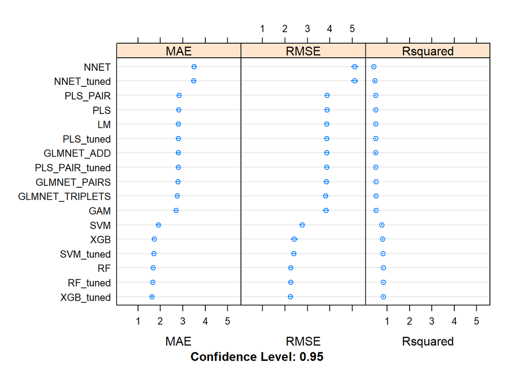

```r
all_models %>% resamples() %>% dotplot()
```

Plot the RMSE.

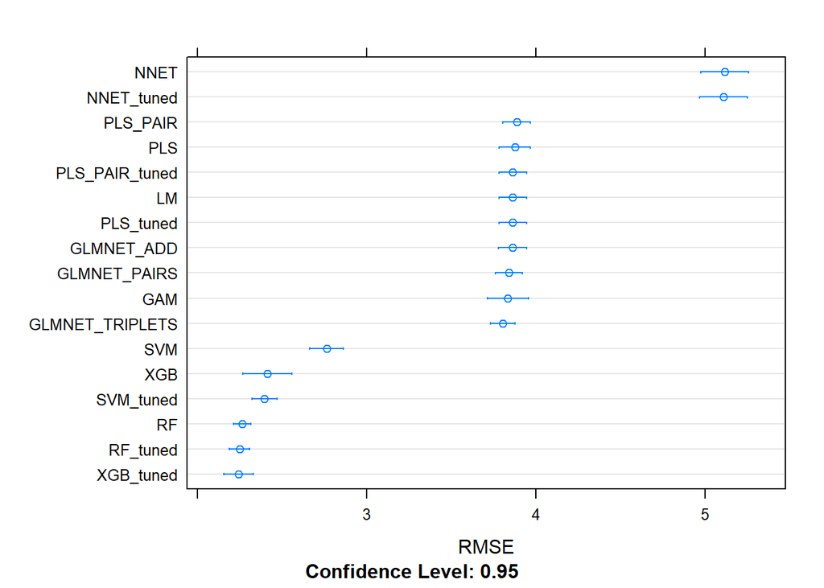

```r
all_models %>% resamples() %>% dotplot(metric = reg_metric)
```

**Gradient Boosted Tree (tuned)** ended up to be the best model based on the plot because it has the lowest RMSE. The second and third best are Random Forest (tuned) and Random Forest. It seems that tree-based models outperform here.

Print the RMSE for the best model.

```r
fit_xgb_tuned$results[reg_metric] %>% min()
```

```
## [1] 2.240992
```

Print the best model.

```r
fit_xgb_tuned
```

```
## eXtreme Gradient Boosting
##
## 2013 samples
##    8 predictor
##
## No pre-processing
## Resampling: Cross-Validated (5 fold, repeated 3 times)
## Summary of sample sizes: 1609, 1611, 1611, 1611, 1610, 1609, ...
## Resampling results across tuning parameters:
##
##   eta  max_depth  nrounds  RMSE      Rsquared   MAE
##   0.1  1           10      4.697862  0.3370127  3.305359
##   0.1  1           20      4.420151  0.4115679  3.101736
##   0.1  1           30      4.247485  0.4407508  2.985364
##   0.1  1           40      4.143691  0.4557131  2.914384
##   0.1  1           50      4.080413  0.4613757  2.872724
##   0.1  1           60      4.037882  0.4659700  2.842905
##   0.1  1           70      4.010833  0.4691825  2.815746
##   0.1  1           80      3.987321  0.4724860  2.791900
##   0.1  1           90      3.975185  0.4729160  2.775641
##   0.1  1          100      3.962056  0.4744065  2.761141
##   0.1  2           10      4.203903  0.5525229  2.965109
##   0.1  2           20      3.729420  0.6003188  2.666204
##   0.1  2           30      3.545712  0.6180350  2.534915
##   0.1  2           40      3.430135  0.6339986  2.439598
##   0.1  2           50      3.330039  0.6517981  2.360107
##   0.1  2           60      3.247483  0.6660912  2.299776
##   0.1  2           70      3.198135  0.6740496  2.262021
##   0.1  2           80      3.162872  0.6793704  2.231916
##   0.1  2           90      3.131120  0.6842725  2.207733
##   0.1  2          100      3.103210  0.6887199  2.188076
##   0.1  3           10      3.898181  0.6424800  2.752403
##   0.1  3           20      3.302504  0.6968780  2.369181
##   0.1  3           30      3.065976  0.7233214  2.200831
##   0.1  3           40      2.898586  0.7449871  2.080142
##   0.1  3           50      2.820435  0.7535468  2.014859
##   0.1  3           60      2.782614  0.7571317  1.980082
##   0.1  3           70      2.754340  0.7604028  1.959187
##   0.1  3           80      2.728680  0.7632602  1.937761
##   0.1  3           90      2.700454  0.7668723  1.918020
```

[output cut: 447 more lines]

```
##   0.8  6           70      2.970341  0.6989449  2.142796
##   0.8  6           80      2.972372  0.6986148  2.144837
##   0.8  6           90      2.972168  0.6986384  2.144558
##   0.8  6          100      2.973004  0.6984842  2.144826
##
## Tuning parameter 'gamma' was held constant at a value of 0
## Tuning
##
## Tuning parameter 'min_child_weight' was held constant at a value of 1
##
## Tuning parameter 'subsample' was held constant at a value of 1
## RMSE was used to select the optimal model using the smallest value.
## The final values used for the model were nrounds = 100, max_depth = 6, eta
##  = 0.1, gamma = 0, colsample_bytree = 0.8, min_child_weight = 1 and subsample
##  = 1.
```

## Save the best model

Save the model.

```r
fit_xgb_tuned %>% readr::write_rds('mod_reg_best.rds')
```